# Date estimation analysis

### Regressions

We suspect participants responses may be driven by properties of the advice only, while the properties of the advisor are ignored (i.e. participants behave as if all trials are discrete). If this is the case, there will be no differences between regression lines for advisors when regressing predictors vs WoA.

#### Distance x WoA

Previous research indicates a u-shaped curve for distance x woa - first we check if this is appropriate.

|  | Res.Df | RSS | Df | Sum of Sq | F | Pr(>F) |
| --- | --- | --- | --- | --- | --- | --- |
| 1 | 558 | 93.97528 | NA | NA | NA | NA |
| 2 | 557 | 88.03167 | 1 | 5.943606 | 37.60679 | 1.641053e-09 |

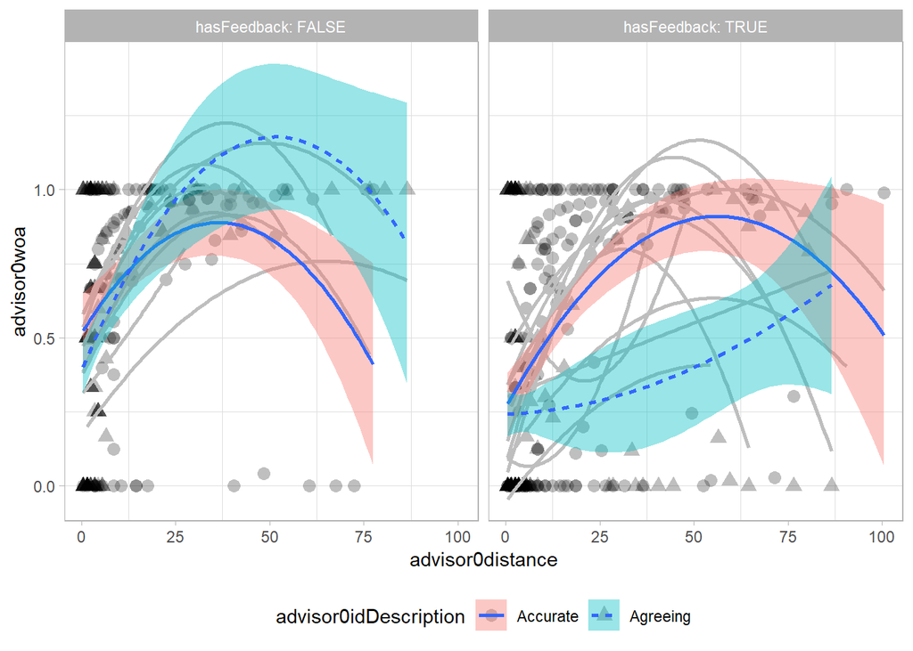

#### Advice error x WoA

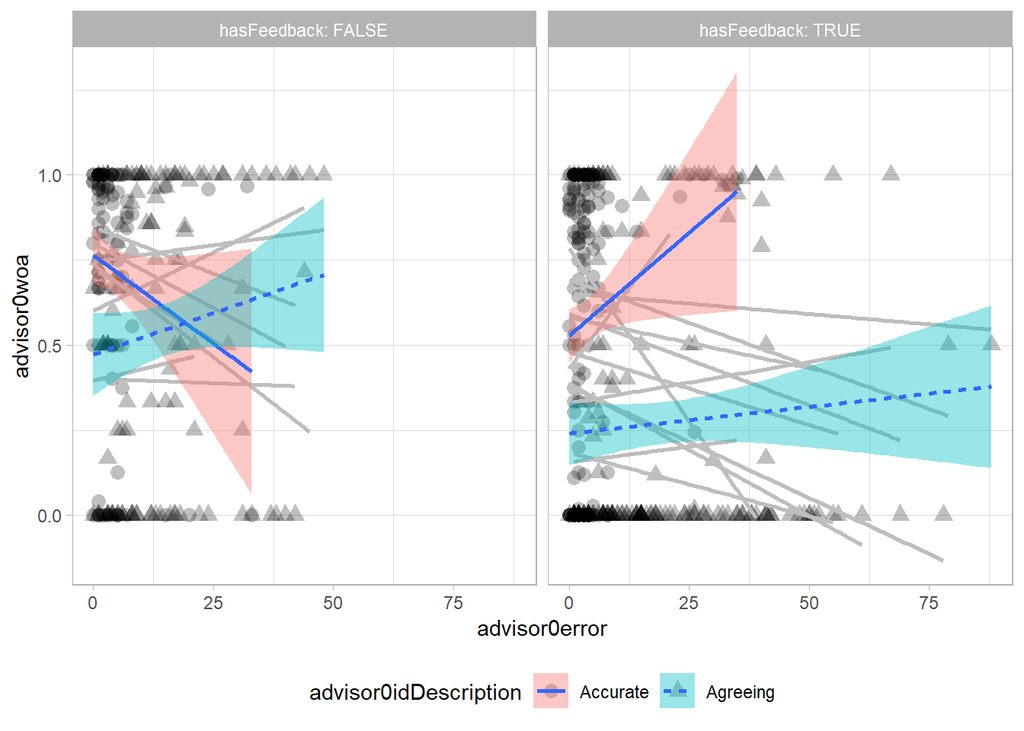

#### Initial decision error x WoA

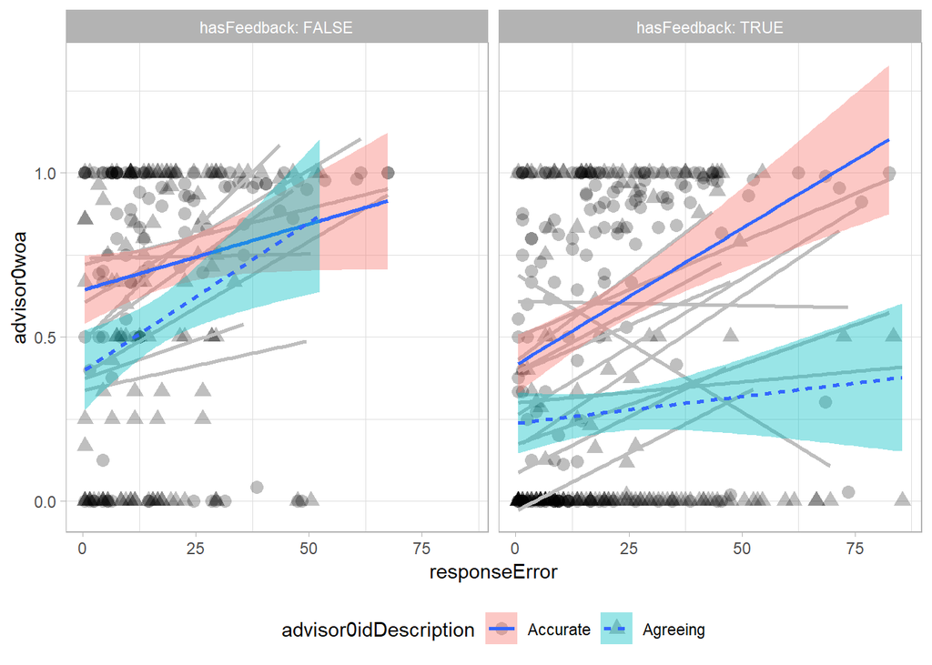

#### Marker width x WoA

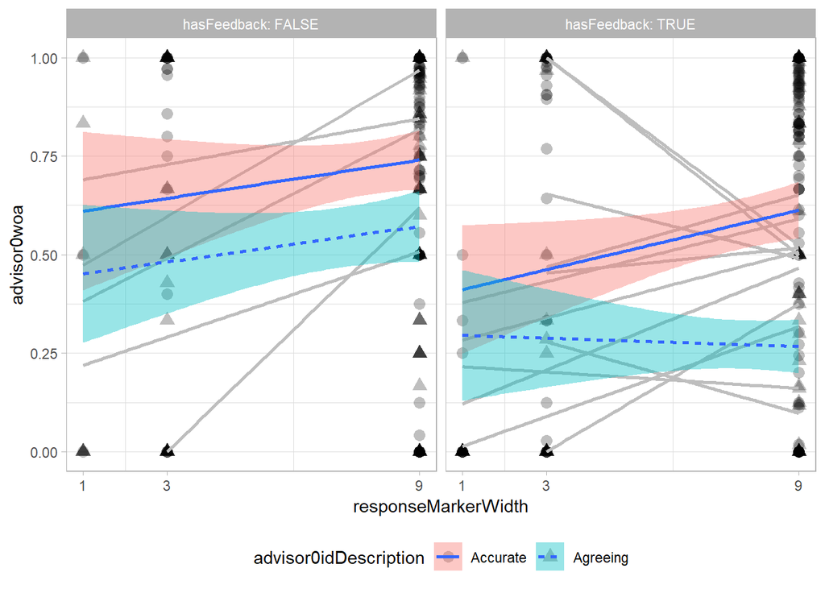

## Questionnaires

### Advisors

First we want to take a look at how the advisor questionnaire data break down.

[output not shown]

[figure not shown]

Next we want to see whether participants who rate an advisor highly are also more influenced by that advisor’s advice.

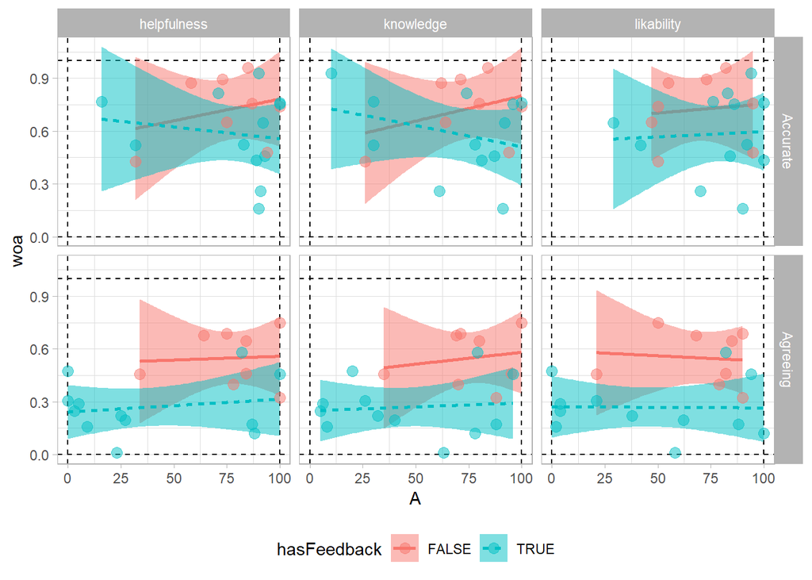

## Update modelling

We can model some of the changes investigated above as a function of the properties of each of the advisors on the trial. These models can be thought of as constituting more specifc hypotheses about the mechanics underlying the updating of advice quality on the basis of experience.

As a sanity check, we can run the established models of advisor updating as a consequence of feedback in the feedback condition. In this model, advisors’ advice is adjusted as a consequence of the feedback received by an amount equal to a free learning rate parameter:
$$\omega_a^{t+1} = \omega_a^t + \lambda f(e_{a}^t, v^t)$$
where $\omega_a^t$ is the credibility of advisor $a$ on trial $t$, $\lambda$ is a learning rate parameter, $f(x,y)$ is a fitness function for an estimate $x$ and target value $y$, $e_a^t$ is the estimate provided by advisor $a$ on trial $t$, and $v^t$ the target value on trial $t$.

In the simplest case, $f(x, y)$ takes values of -1 or +1 for incorrect and correct estimates, respectively, while in other cases it may be continuous, e.g. the reciprocal of the error.

## Credits

### Acknowledgements

Thanks as always to Nick Yeung and the other folks at the [ACC Lab](https://www.psy.ox.ac.uk/research/attention-cognitive-control-lab).

### R Packages

| Package | Citations |
| --- | --- |
| base | R Core Team (2018). R: A language and environment for statistical computing. R Foundation for Statistical Computing, Vienna, Austria. URL https://www.R-project.org/. |
| ez | Michael A. Lawrence (2016). ez: Easy Analysis and Visualization of Factorial Experiments. R package version 4.4-0. https://CRAN.R-project.org/package=ez |
| prettyMD | Matt Jaquiery (2018). prettyMD: Format Test Outputs with Markdown. R package version 0.1.0. |
| knitr | Yihui Xie (2018). knitr: A General-Purpose Package for Dynamic Report Generation in R. R package version 1.20. Yihui Xie (2015) Dynamic Documents with R and knitr. 2nd edition. Chapman and Hall/CRC. I… |
| BANOVA |  |
| BayesFactor | Richard D. Morey and Jeffrey N. Rouder (2018). BayesFactor: Computation of Bayes Factors for Common Designs. R package version 0.9.12-4.2. https://CRAN.R-project.org/package=BayesFactor |
| Matrix | Douglas Bates and Martin Maechler (2018). Matrix: Sparse and Dense Matrix Classes and Methods. R package version 1.2-14. https://CRAN.R-project.org/package=Matrix |
| coda | Martyn Plummer, Nicky Best, Kate Cowles and Karen Vines (2006). CODA: Convergence Diagnosis and Output Analysis for MCMC, R News, vol 6, 7-11 |
| lsr | Navarro, D. J. (2015) Learning statistics with R: A tutorial for psychology students and other beginners. (Version 0.5) University of Adelaide. Adelaide, Australia |
| curl | Jeroen Ooms (2018). curl: A Modern and Flexible Web Client for R. R package version 3.2. https://CRAN.R-project.org/package=curl |
| forcats | Hadley Wickham (2018). forcats: Tools for Working with Categorical Variables (Factors). R package version 0.3.0. https://CRAN.R-project.org/package=forcats |
| stringr | Hadley Wickham (2018). stringr: Simple, Consistent Wrappers for Common String Operations. R package version 1.3.1. https://CRAN.R-project.org/package=stringr |
| dplyr | Hadley Wickham, Romain François, Lionel Henry and Kirill Müller (2018). dplyr: A Grammar of Data Manipulation. R package version 0.7.8. https://CRAN.R-project.org/package=dplyr |
| purrr | Lionel Henry and Hadley Wickham (2018). purrr: Functional Programming Tools. R package version 0.2.5. https://CRAN.R-project.org/package=purrr |
| readr | Hadley Wickham, Jim Hester and Romain Francois (2017). readr: Read Rectangular Text Data. R package version 1.1.1. https://CRAN.R-project.org/package=readr |
| tidyr | Hadley Wickham and Lionel Henry (2018). tidyr: Easily Tidy Data with ‘spread()’ and ‘gather()’ Functions. R package version 0.8.1. https://CRAN.R-project.org/package=tidyr |
| tibble | Kirill Müller and Hadley Wickham (2018). tibble: Simple Data Frames. R package version 1.4.2. https://CRAN.R-project.org/package=tibble |
| ggplot2 | H. Wickham. ggplot2: Elegant Graphics for Data Analysis. Springer-Verlag New York, 2016. |
| tidyverse | Hadley Wickham (2017). tidyverse: Easily Install and Load the ‘Tidyverse’. R package version 1.2.1. https://CRAN.R-project.org/package=tidyverse |
| testthat | Hadley Wickham. testthat: Get Started with Testing. The R Journal, vol. 3, no. 1, pp. 5–10, 2011 |

### Funding

Matt Jaquiery is funded by a studentship from the [Medical Research Council](https://mrc.ukri.org/) (reference 1943590) and the University of Oxford [Department of Experimental Psychology](https://www.psy.ox.ac.uk/) (reference 17/18_MSD_661552).